[O’Hara on GitHub](https://github.com/oharac)

# Determine temperature rise stressor per spp

Compiled on Fri Sep 15 15:30:22 2023 by ohara

```r
knitr::opts_chunk$set(echo = TRUE, message = FALSE, warning = FALSE)

library(terra)
library(sf)
library(tidyverse)
library(here)
library(oharac)

source(here('common_fxns.R'))
source('stressor_fxns.R') ### in same dir as this Rmd
```

# 1 Summary

Using a map of mean SST over the past five years (2016-2020), identify species-specific stressor based on the species’ thermal envelope (determined from AquaMaps envelopes or IUCN-similar envelopes).

For each unique thermal envelope (i.e., multiple species might share the same absolute max and preferred max):

- Identify the base stressor layer using Mel’s function to convert mean temperature to 0-1 stressor
  - If mean temp exceeds absolute max, stressor = 1
  - If mean temp is below preferred max, stressor = 0
  - Otherwise stressor scales linearly with temperature from preferred max to absolute max
  - Not going to worry about temps below preferred/absolute min temps
- For each species with this thermal envelope, mask the base stressor layer with the species range and save out as .csv

# 2 Data

# 3 Methods

## 3.1 Read in mean temp map

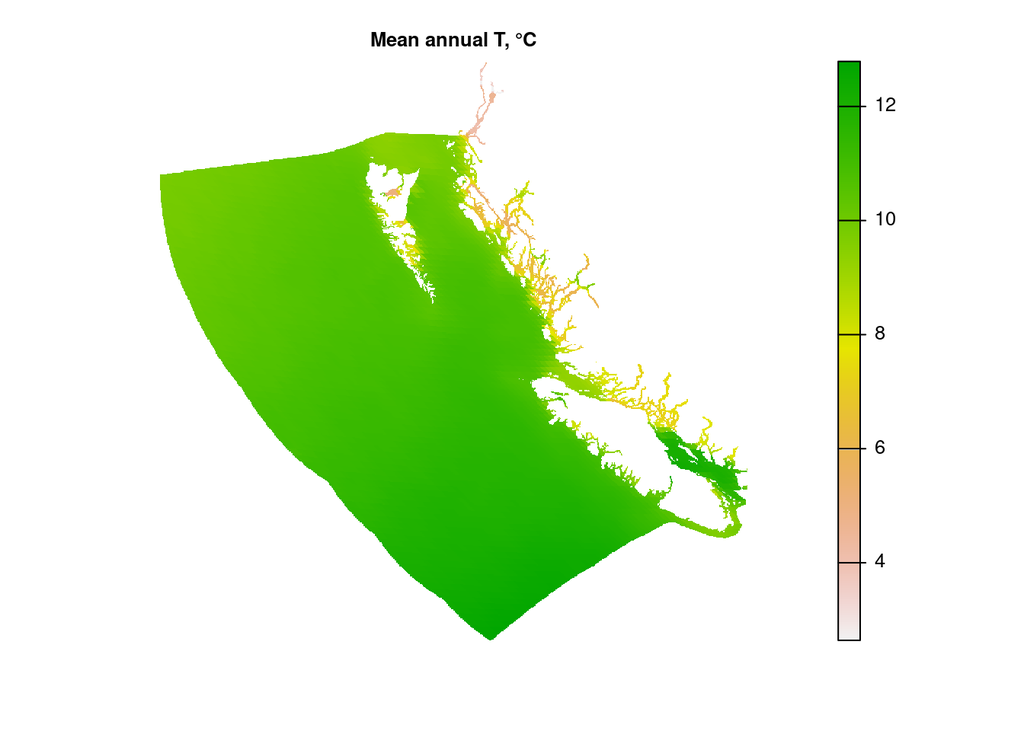

```r
mean_T_f <- 'int/mean_T_rast_bc_1km.tif'

if(!file.exists(mean_T_f)) {
  mean_T_rast_mol <- rast(file.path('/home/shares/ohi/stressors_2021/_dataprep',
                                'SST_past_present/final_avg_tmp/sst_avg_2016-2020.tif'))
  # plot(mean_T_rast_mol, axes = FALSE, main = 'Mean annual T, °C')
  # class       : SpatRaster
  # dimensions  : 1814, 3617, 1  (nrow, ncol, nlyr)
  # resolution  : 10000, 10000  (x, y)
  # extent      : -18086282, 18083718, -9069952, 9070048  (xmin, xmax, ymin, ymax)
  # coord. ref. : +proj=moll +lon_0=0 +x_0=0 +y_0=0 +datum=WGS84 +units=m +no_defs
  # source      : sst_avg_2016-2020.tif
  # name        : sst_avg_2016-2020
  # min value   :         -1.548435
  # max value   :         30.611729

  ocean_r <- rast(here('_spatial/ocean_bc_1km.tif'))

  mean_T_rast_bc <- project(mean_T_rast_mol, ocean_r, method = 'near')

  mean_T_rast_mask <- mean_T_rast_bc %>%
    mask(ocean_r) %>%
    round(2) ### 0.1dC should be adequate precision

  writeRaster(mean_T_rast_mask, mean_T_f, overwrite = TRUE)
}

mean_T_rast <- rast(mean_T_f)

plot(mean_T_rast, axes = FALSE, main = 'Mean annual T, °C')
```

## 3.2 Determine thermal envelope for species

For AquaMaps read from their envelope data (using `get_am_spp_envelopes()` helper function); for IUCN, read from results of script `6a_thermal_tolerances_estimate_iucn.Rmd`.

Here we are calculating for all AquaMaps and IUCN maps, regardless of whether there is overlap or the number of occur_cells is too low. We can always ignore those maps later.

```r
am_dir <- '/home/shares/ohi/spp_vuln/aquamaps_2021'

get_am_spp_envelopes <- function() {
  env_file <- file.path(am_dir, 'species_envelope_summary.csv')

  ### create a tidy summary of environmental envelopes
  if(!file.exists(env_file)) { ### create from scratch
    env_info <- data.table::fread(file.path(am_dir, 'ver10_2019_hspen.csv')) %>%
      janitor::clean_names() %>%
      rename(am_sid = species_id)

    params <- c('depth', 'temp', 'salinity', 'prim_prod', 'ice_con', 'oxy', 'land_dist')
    prm_or <- paste0(params, collapse = '|')
    dist_vals <- c('min', 'pref_min', 'mean', 'pref_max', 'max')
    env_sum_df <- env_info %>%
      rename(depth_mean = mean_depth) %>%
      select(am_sid, contains(params)) %>%
      gather(param_full, value, -am_sid) %>%
      mutate(param = str_extract(param_full, prm_or),
             dist = str_replace(param_full, paste0('(', prm_or, ')_'), '')) %>%
      select(-param_full) %>%
      spread(dist, value) %>%
      filter(yn == 1) %>%
      select(-yn) %>%
      gather(dist, value, -am_sid, -param) %>%
      mutate(dist = factor(dist, levels = dist_vals),
             value = ifelse(param == 'depth', log10(value + 1), value),
             param = ifelse(param == 'depth', 'log10_depth', param))

    write_csv(env_sum_df, env_file)
  }
  env_df <- data.table::fread(env_file) %>%
    mutate(am_sid = tolower(am_sid))
  return(env_df)
}
```

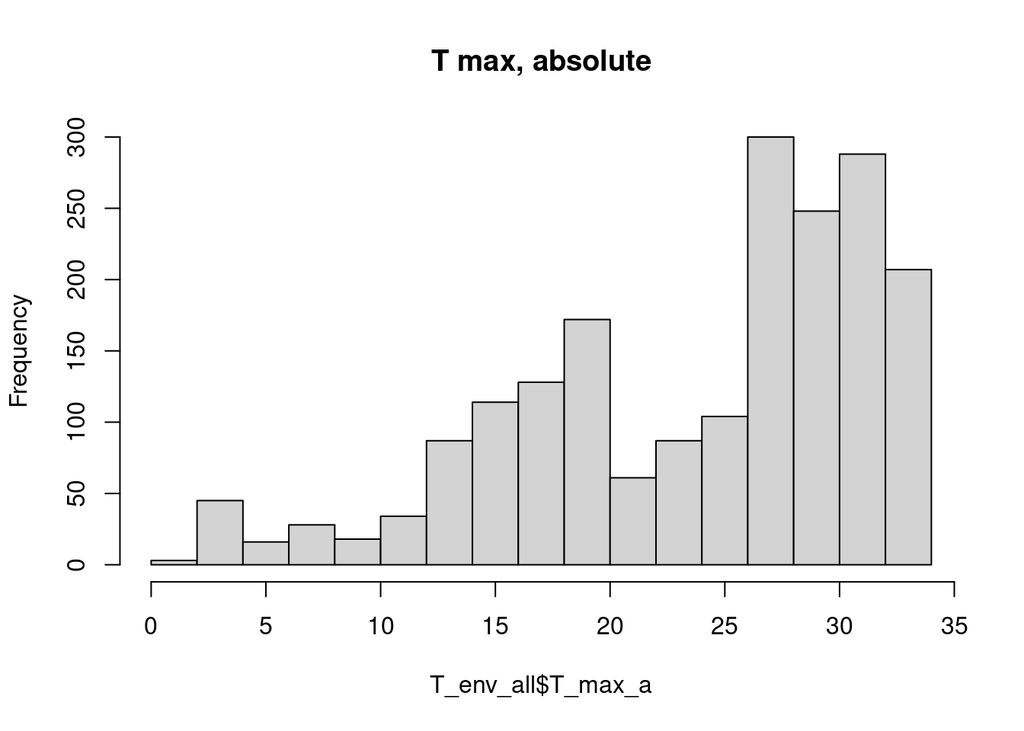

```r
am_sids  <- read_csv(here('_data/am_spp_bc.csv')) %>%
  select(sciname, am_sid) %>%
  distinct()

spp_info <- get_spp_info() %>%
  select(sciname = species, iucn_sid, src, map_f) %>%
  distinct() %>%
  left_join(am_sids, by = 'sciname')


am_T_env <- get_am_spp_envelopes() %>%
  filter(param == 'temp' & dist %in% c('max', 'pref_max')) %>%
  spread(dist, value) %>%
  inner_join(am_sids, by = 'am_sid') %>%
  select(am_sid, sciname, T_max_a = max, T_max_p = pref_max)

iucn_derived_T_envs <- read_csv(here('1_setup/stressors/int/iucn_spp_thermal_env.csv')) %>%
  select(iucn_sid, iucn_tmaxa = T_max_a, iucn_tmaxp = T_max_p) %>%
  filter(iucn_sid %in% spp_info$iucn_sid)

iucn_T_env <- spp_info %>%
  left_join(am_T_env, by = c('am_sid', 'sciname')) %>%
  left_join(iucn_derived_T_envs, by = c('iucn_sid')) %>%
  mutate(T_max_a = ifelse(is.na(T_max_a), iucn_tmaxa, T_max_a),
         T_max_p = ifelse(is.na(T_max_p), iucn_tmaxp, T_max_p)) %>%
  filter(src == 'iucn') %>%
  select(iucn_sid, sciname, T_max_a, T_max_p) %>%
  distinct()

T_env_all <- bind_rows(am_T_env, iucn_T_env)

hist(T_env_all$T_max_a, main = 'T max, absolute')
```

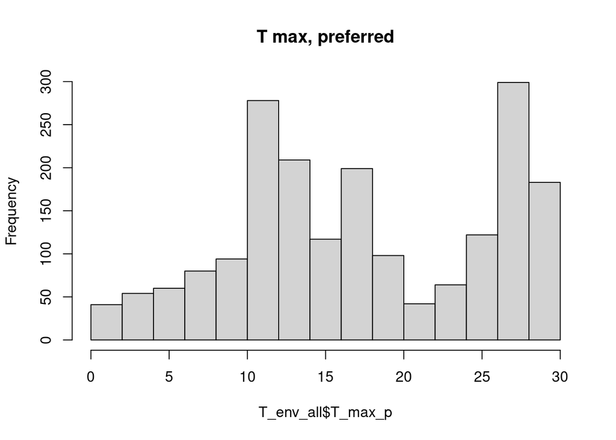

```r
hist(T_env_all$T_max_p, main = 'T max, preferred')
```

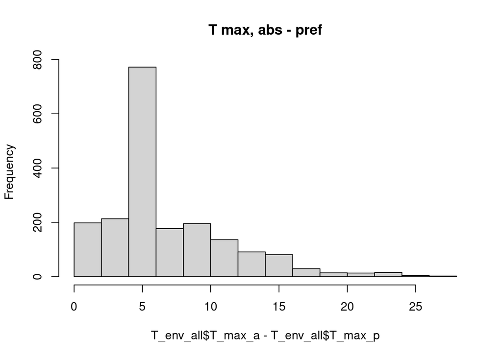

```r
hist(T_env_all$T_max_a - T_env_all$T_max_p, main = 'T max, abs - pref')
```

## 3.3 Process species pressures

For each niche group:

- calculate the pressure map using the `calc_T_max_prs()` function defined below
- convert the resulting pressure map to a data.frame based on cell ID and mean annual temp
- loop over each species in the niche:
  - read in the species distribution as a .csv from the appropriate source (AquaMaps or IUCN)
  - intersect the species distribution with the temperature pressure map for this thermal niche
  - write out the resulting csv of cell_id and pressure, with species info in filename.

### 3.3.1 Function `calc_T_max_prs()`

To determine the pressure on a species based on its thermal tolerance and mean annual temperature in a cell:

- If the mean annual temperature meets or exceeds the species’ T_max_a, pressure = 1.
- If the mean annual temperature meets or is lower than the species’ T_max_p, pressure = 0.
- If the mean annual temperature T_max_p < mean annual T < T_max_a, scale linearly from 0 to 1.

```r
### before rounding, 10175 gps
### * after rounding to 0.1° 6191 gps
### * after rounding to 0.25° 3397 gps
### * after rounding to 0.5° 1415 gps
### * rounding pref down and abs up (floor/ceiling), 462 gps
# gp_check <- T_env_all %>%
#   # mutate(T_max_a = round(T_max_a, 1), T_max_p = round(T_max_p, 1)) %>%
#   # mutate(T_max_a = ceiling(4 * T_max_a) / 4, T_max_p = floor(4 * T_max_p) / 4) %>%
#   mutate(T_max_a = ceiling(2 * T_max_a) / 2, T_max_p = floor(2 * T_max_p) / 2) %>%
#   # mutate(T_max_a = ceiling(T_max_a), T_max_p = floor(T_max_p)) %>%
#   group_by(T_max_a, T_max_p) %>%
#   summarize(n = n())

max_T_bc <- minmax(mean_T_rast)[2]

### For synonymous spp with multiple AquaMaps instances, take mean of temps
T_env_rounded <- T_env_all  %>%
  mutate(src = ifelse(is.na(am_sid), 'iucn', 'am'),
         id  = ifelse(src == 'iucn', iucn_sid, str_replace_all(sciname, '[^a-z]+', '_'))) %>%
  group_by(sciname, id, src) %>%
  summarize(T_max_a = mean(T_max_a), T_max_p = mean(T_max_p),
            .groups = 'drop') %>%
  mutate(T_max_a = ceiling(2 * T_max_a) / 2, T_max_p = floor(2 * T_max_p) / 2) %>%
  ### combine all spp with T_max_p greater than observed max mean T
  mutate(T_max_a = ifelse(T_max_p > max_T_bc, max_T_bc, T_max_a),
         T_max_p = ifelse(T_max_p > max_T_bc, max_T_bc, T_max_p))

gps_df <- T_env_rounded %>%
  group_by(T_max_a, T_max_p) %>%
  summarize(n_spp = n(), .groups = 'drop') %>%
  arrange(desc(n_spp)) %>%
  mutate(gp = 1:n())

T_env_to_process <- T_env_rounded %>%
  left_join(gps_df, by = c('T_max_a', 'T_max_p')) %>%
  filter(!is.na(sciname)) %>%
  distinct()
```

```r
calc_T_max_prs <- function(abs, pref, rast = mean_T_rast) {
  #t0 <- Sys.time()
  pressure <- (1/(abs - pref))*(rast - pref)
  pressure[pressure < 0] <- 0
  pressure[pressure > 1] <- 1
  return(pressure %>% setNames('therm_prs'))
  #Sys.time()-t0
}

# tmp <- calc_T_max_prs(abs = 30, pref = 5, rast = mean_T_rast)
# plot(tmp)

get_spp_map <- function(map_f) {

  if(!file.exists(map_f)) stop('Map does not exist: ', basename(map_f))

  src <- basename(map_f) %>% str_remove('_.+')
  spp_map <- read_csv(map_f, show_col_types = FALSE)

  ### filter for valid cells - AM prob ≥ 0.50, IUCN presence != 5
  prob_thresh <- 0.50
  if(src == 'am') {
    spp_map <- spp_map %>% filter(prob >= prob_thresh)
  } else {
    spp_map <- spp_map %>% filter(presence != 5)
  }

  return(spp_map %>% select(cell_id))
}

process_spp_therm_str <- function(j, spp_env_df, t_prs_df, out_fstem) {
  # for(j in 1:nrow(spp_envs)) {
  ### j <- 1
  ### j <- 1261
  ### get species range map

  spp_env <- spp_env_df[j, ]
  spp <- spp_env$sciname
  src <- spp_env$src
  id  <- spp_env$id

  out_f <- sprintf(out_fstem, src, id)

  if(file.exists(out_f)) {
    message('File ', basename(out_f), ' exists... skipping!')
    return(NULL)
  }

  ### file doesn't exist; process it!
  message('Processing ', basename(out_f), ' (', j, ' of ', nrow(spp_envs),
    ' in group ', i, ' of ', nrow(gps_df), ')...')

  map_stem <- here_anx('spp_maps_bc/%s_spp_bc_%s.csv')
  map_f <- sprintf(map_stem, src, id)
  spp_map <- get_spp_map(map_f)

  ### inner join with temp pressure dataframe
  spp_temp_df <- spp_map %>%
    oharac::dt_join(t_prs_df, by = 'cell_id', type = 'inner') %>%
    distinct()

  if(nrow(spp_temp_df) == 0) {
    spp_temp_df <- data.frame(cell_id = -1,
                              therm_prs = NA)
    message('... Zero length result for ', basename(out_f))
  } else {
    message('... results df for ', spp, ' from ', src, ' contains ', nrow(spp_temp_df),
            ' rows...')
  }

  ### to check results:
  # x <- rast(here('_spatial/ocean_bc_1km.tif'))
  # y <- x %>% setValues(1:ncell(.))
  # df <- spp_temp_df %>% complete(cell_id = 1:ncell(y)) %>% arrange(cell_id)
  # z <- y %>% setValues(df$therm_prs)
  # plot(z)

  ### write out to file
  write_csv(spp_temp_df, out_f)

  return(basename(out_f)) ### to check for errors in result...

}
```

```r
ocean_r <- rast(here('_spatial/ocean_bc_1km.tif'))
out_fstem <- here_anx('stressors/max_temp/%s_spp_max_temp_%s.csv')
# zxcv <- list.files(dirname(out_fstem), full.names = TRUE, pattern = 'spp_max_temp')
# r <- ocean_r %>% setValues(1:ncell(.))
# df <- read_csv(zxcv[25]) %>% complete(cell_id = 1:ncell(r))
# x <- r %>% setValues(df$therm_prs)

ptm <- proc.time()

for(i in 1:nrow(gps_df)) {
  ### i <- 13
  ### i <- 300
  spp_envs <- T_env_to_process %>%
    filter(gp == i)

  tmax_a <- spp_envs$T_max_a[1] ### should all be identical
  tmax_p <- spp_envs$T_max_p[1] ### should all be identical

  out_fs <- sprintf(out_fstem, spp_envs$src, spp_envs$id)
  if(all(file.exists(out_fs))) {
    message(i, ' of ', nrow(gps_df), ': file exists for all ', nrow(spp_envs),
            ' species with thermal niche from ', tmax_p, ' to ', tmax_a, '°C... skipping this group!')
    next()
  } else {
    spp_envs <- spp_envs[!file.exists(out_fs), ]
  }

  ### not all files exist for this group:
  message(i, ' of ', nrow(gps_df), ': Processing ', nrow(spp_envs),
          ' species with thermal niche from ', tmax_p, ' to ', tmax_a, '°C...')

  t_prs_i_rast <- calc_T_max_prs(abs = tmax_a, pref = tmax_p)
  ### plot(t_prs_i_rast, axes = FALSE, main = sprintf('Therm prs for range %s to %s', tmax_p, tmax_a))

  t_prs_i_df <- data.frame(values(t_prs_i_rast),
                           cell_id   = 1:ncell(t_prs_i_rast)) %>%
    filter(!is.na(therm_prs)) %>%
    mutate(therm_prs = round(therm_prs, 5)) ### drop unreasonable precision

  tmp <- parallel::mclapply(1:nrow(spp_envs), mc.cores = 4,
           FUN = process_spp_therm_str,
             t_prs_df   = t_prs_i_df,
             out_fstem  = out_fstem,
             spp_env_df = spp_envs
           )
}

ptm <- proc.time() - ptm
```

Elapsed time for processing: 853.745 seconds.